# Predicting Wildfires Based on Temperature and Precipitation

## Introduction

This document is part of my Data Incubator application.

In Colorado, more and more people are moving to the wildland-urban interface. We have seen property values in our scenic mountain towns increasing steadily. Just 30 minutes from Denver, the town of Evergreen offers mountain-living with the convenience of living close to a major city with all the amenities one could want.

This growth in population and construction is at risk to wildland fires. Climate change has increased the frequency and intensity of wildfires in the Western US over the past decade and this problem is only expected to get worse in the future. In the past decade alone, Colorado has experience at least 3 costly fire events that destroyed property and lives.

- The High Park Fire in 2012 near Ft. Collins destroyed estimated to cost $33.5 million
- The Waldo Canyon fire in 2012 near Colorado Springs estimated to $453.7 million.
- The Four mile Canyon fire in 2014 near Boulder that cost $217 million.

In other populated Western States like California and Washington, wildfires pose a similar if not greater risk to property than Colorado. One only needs to look to the recent Northern California fires that affected Sonoma and Napa counties that cost a record $9.4 billion in insured damage.

The ability to quantify neighborhood and community risk to wildfires would be of economic value for real-estate developers and insurance agencies.

I am proposing to build predictive models that will estimate the likelihood of a wildfire for the Western United States using data from NASA and NOAA satellite products. These models will use a relatively untapped data resource of NASA and NOAA remote-sensor satellite products.

To demonstrate the feasibility of this project, I will use Palmer Drought Index data that uses temperature and precipitation satellite products from National Oceanic and Atmospheric Administration (NOAA) to plot the mean drought index for Colorado from 1980 to 2014. I will also plot the number of wildfires in Colorado from 1980 to 2014 as well.

I will use the following packages to create the plot. The tidyverse package is a general data-wrangling package that also includes ggplot2 graphical package. The ncdf4 package opens connections to .nc gridded array files that are commonly used by NOAA for efficiently storing multi-dimensional data. The sf package will be used to open up a shape file of wildfire locations.

```r
# libraries
library(tidyverse)
library(ncdf4)
library(sf)
```

```r
# knitr options
knitr::opts_chunk$set(fig.width = 8, fig.height = 6)
```

## Drought Index

Opening connection to Palmer Drought Index (PDI) file from Colorado.

```r
# open drought index nc conncection
di_nc <- nc_open("./data/pdi_colorado.nc")
```

Wrangling PDI from 3-D array to a 2-D matrix.

```r
# extract lat/lon points and expand grid
lat <- ncvar_get(di_nc, varid = "lat")
# lons need to be negative rather than degrees west
lon <- ncvar_get(di_nc, varid = "lon")
coords <- as.matrix(expand.grid(lon,lat))
# extract recent montly air temp where each month is a column
pdsi <- ncvar_get(di_nc, varid = "pdsi")

# matrix
pdsi_mat <- apply(pdsi, 3, as.vector)
# create date column names
date <- as.character(seq(as.Date("1980-01-01"), as.Date("2014-12-01"),
                         by = "month"))
# assign date names to temp matrix
colnames(pdsi_mat) <- date
```

Preparing data frame for plotting.

```r
# pdsi matrix
colnames(coords) <- c("lon", "lat")

group <- 1:9
# group
pdsi_df <- data.frame(group, coords, pdsi_mat)
glimpse(pdsi_df)
```

```
## Observations: 9
## Variables: 423
## $ group       <int> 1, 2, 3, 4, 5, 6, 7, 8, 9
## $ lon         <dbl> -108.75, -106.25, -103.75, -108.75, -106.25, -103....
## $ lat         <dbl> 36.25, 36.25, 36.25, 38.75, 38.75, 38.75, 41.25, 4...
## $ X1980.01.01 <dbl> 2.027158, 3.188954, 1.623382, 1.994238, 2.599828, ...
## $ X1980.02.01 <dbl> 2.707055, 3.628377, 1.343466, 2.627664, 2.927587, ...
## $ X1980.03.01 <dbl> 2.838612, 3.835244, 1.355624, 3.066176, 2.972947, ...
## $ X1980.04.01 <dbl> 2.7559106, 3.9443605, 2.6866462, 3.2311931, 3.2378...
## $ X1980.05.01 <dbl> 2.5890930, 4.0881681, 3.1159599, 3.8768282, 3.7542...
## $ X1980.06.01 <dbl> -0.02565112, -0.18123281, -0.89058787, 3.54623008,...
## $ X1980.07.01 <dbl> -0.519466758, -0.822855294, -2.531148672, 0.002169...
## $ X1980.08.01 <dbl> -0.59479880, -1.07179463, -3.32126904, -0.09954655...
## $ X1980.09.01 <dbl> -0.4342344, -0.8927641, -2.7320495, -0.2132086, -0...
## $ X1980.10.01 <dbl> -0.57979226, -0.96868402, -3.19790339, -0.05827889...
```

[output cut: 410 more lines]

```r
# date for plotting
date_col <- as.data.frame(seq(as.Date("1980-01-01"), as.Date("2014-12-01"),
                        by = "month"))

# make temp matrix and take mean for state
co_di <- pdsi_df %>%
  select(-lon, -lat) %>%
  gather(key = date, value = pdi, -group) %>%
  mutate(pdi_invert = -(pdi),
    Date = as.Date(gsub("X", "", gsub("\\.","-", date)))) %>%
  group_by(Date) %>%
  summarise(mean_pdi_invert = mean(pdi_invert)) %>%
  mutate(month = factor(months(Date),
   levels = c("January", "February", "March", "April", "May", "June", "July",
               "August", "September", "October", "November", "December")))
```

### Plot of Colorado Monthly Mean Drought Index 1980-2014

Plot of inverted drought index (measure that accounts for temperature and precipitation) for Colorado by Month. General trend across the state and for all months indicates the state is getting dryer over time.

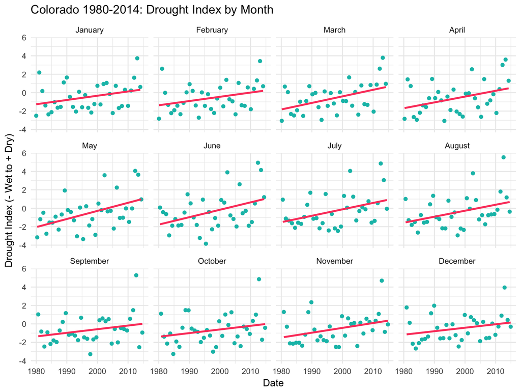

```r
# drought plot
ggplot(co_di, aes(x=Date, y=mean_pdi_invert)) +
  geom_point(color = "#06beb6") +
  geom_smooth(method = "lm", se = F, color = "#fc466b") +
  facet_wrap(~month) +
  ylab("Drought Index (- Wet to + Dry)") +
  ggtitle("Colorado 1980-2014: Drought Index by Month") +
  theme_minimal()
```

## Wildfires

Using US Forest Service historic wildfire shape file data and subletting to Colorado from 1980 to 2014.

```r
# import wildfires for US
wildfire <- st_read(dsn = "./data/wf_usfs_1980_2016/",
                    layer = "wf_usfs_1980_2016")
# subset to colorado and limit to time period of drought index
co_fires <- wildfire %>%
  filter(STATE == "Colorado") %>%
  filter(STARTDATED <= "2014-12-31") %>%
  filter(Duplicate_ == 0) %>%
  mutate(Date = lubridate::floor_date(STARTDATED, unit = "months"))

# extract lat lonts
fire_coords <- data.frame(st_coordinates(co_fires)) %>%
  rename("lon"=X, "lat"=Y)

# join in with co fires
co_fire_summary <- co_fires %>%
  bind_cols(fire_coords) %>%
  group_by(Date) %>%
  summarise(n_fires = n(), total_acres = sum(TOTALACRES)) %>%
  mutate(month = factor(months(Date),
    levels = c("January", "February", "March", "April", "May", "June", "July",
               "August", "September", "October", "November", "December")))

# remove sf geometrey
st_geometry(co_fire_summary) <- NULL
```

### Plot of Colorado Number of Wildfire Numbers 1980-2014

Plotting number of wildfires of any size by month during the study period. The number of wildfires has been increasing over time for the summer months of June, July, and August.

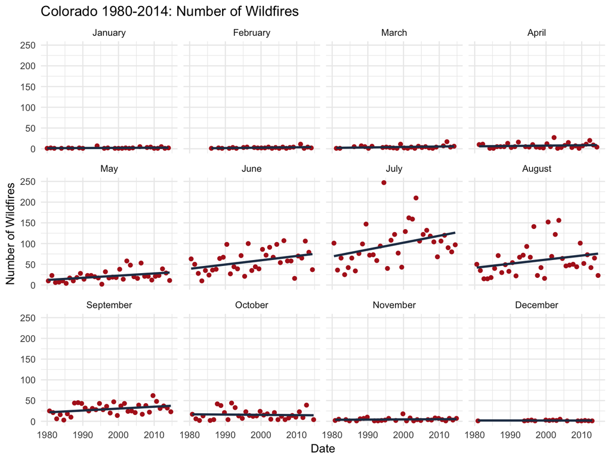

```r
# plot
ggplot(co_fire_summary, aes(x=Date, y = n_fires)) +
  geom_point(color = "#b21f1f") +
  geom_smooth(method = "lm", se=F, color = "#243b55") +
  facet_wrap(~month) +
  ylab("Number of Wildfires") +
  ggtitle("Colorado 1980-2014: Number of Wildfires") +
  theme_minimal()
```

## Conclusion

The increasing drought index during the summer months and the increasing number of wildfires leads me to believe that building a predictive model of likelihood of a wildfire occurring based on factors like drought, temperature, precipitation, and vegetative land cover would be a successful capstone project.